# competition-pointcloud

## Pre-process the point clouds

Before using the cone and cylinder point cloud approaches, the trees for which competition is to be quantified must be extracted from the plot. The most accurate way to do this is with [CloudCompare](https://www.danielgm.net/cc/). Load your point cloud of the whole plot and use the [Segment](https://www.cloudcompare.org/doc/wiki/index.php/Interactive_Segmentation_Tool) function to extract the target tree. Make sure you do not miss any part or include neighbouring trees or their branches, as it is crucial to determine which parts of the point cloud are neighbours and which points belong to the target tree. Pay particular attention to the ground and don’t include any ground points in your target tree’s point cloud, otherwise the tree’s position may be shifted later as the function takes the lowest points into account.

[figure not shown]

After extracting the target tree, export the point cloud by selecting the file in the DB Tree and click File - Save. Do the same for the whole plot, but first clip the point cloud to your area of interest. The best way to do this is to select top view and use the [Cross Section] function (https://www.cloudcompare.org/doc/wiki/index.php/Cross_Section) to clip your point cloud. Make sure that your target tree is not at the edge of the plot. We used 30x30m plots. When exporting/saving the point clouds, you can select .las/.laz, .txt, .csv, … after clicking save, you will be asked to select the output resolution. If you choose a custom resolution or coordinate accuracy, make sure you choose the same for the target tree and the neighbourhood cloud!

## Quantify Competition

Once you have the two point clouds, you can use TreeCompR. Read and validate your point clouds (both the target tree and the neighbourhood).

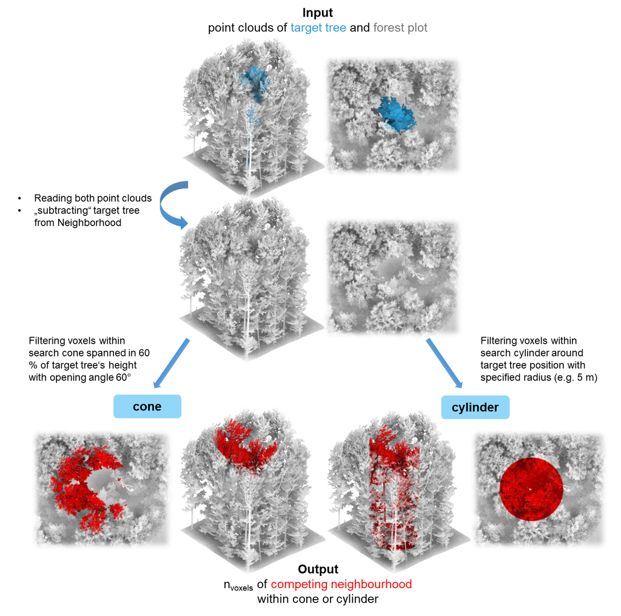

Select the method competition method (comp_method) “cylinder” or “cone” or “both”. Also the position of the center of the cone or cylinder can be “set” either to crown position (“crown_pos”) or base position (“base_pos”). Usually the tree position is calculated by using the lowest points of a tree and take the mean or median, but if the tree is not growing straight, and we want to identify (crown-)competition, we think it is useful to go for the medoid of the crown (crown center). If you want to use the base position, there are additional parameters that you can adjust, as the h_xy (height in m over stem base where position xy should be calculated from) or z_min (minimum number of points in the lowermost 0.1 m of the tree to calculate base position of the tree). Read more on the methods themselves or the settings and sensitivity in [Seidel et al., 2015](https://doi.org/10.1016/j.foreco.2014.10.020), [Metz et al., 2013](https://www.sciencedirect.com/science/article/pii/S0378112713005410) or the original KKL index by [Pretzsch et al., 2002](https://www.sciencedirect.com/science/article/pii/S0378112702000476).

```r
library(TreeCompR)

CI <- compete_pc(forest_source = "../tests/testthat/testdata/neighborhood.txt",
                tree_source = "../tests/testthat/testdata/tree.txt",
                comp_method = "both", # calculate CI in cylinder and cone
                center_position = "crown_pos", #center for cone and cylinder
                cyl_r = 4, #radius in m
                h_cone = 0.6, #set height where the cone starts
                #to open in relation to tree height (0.6 = 60 % of tree height)
                print_progress = "some" #get some information during processing
                )
```

The result is a data frame that you can save or use for further statistical analysis. It contains the name or ID (filename) of the tree, the height of the tree, the center_position used, the CI value(s) and the main parameter settings.

If you want to use the same neighbourhood again, because you have more than one target tree within that plot, you do not need to read the point cloud from the file each time. Read it once with `read_pc()` and use it again. You can also load the target tree outside the `compete_pc()` function.

```r
neighbours <- read_pc("../tests/testthat/testdata/neighborhood.txt")
tree <- read_pc("../tests/testthat/testdata/tree.txt")

CI <- compete_pc(forest_source = neighbours,
                tree_source = tree,
                comp_method = "both", # calculate CI in cylinder and cone
                center_position = "crown_pos", #center for cone and cylinder
                cyl_r = 4, #radius in m
                h_cone = 0.6, #set height where the cone starts
                #to open in relation to tree height (0.6 = 60 % of tree height)
                print_progress = "full" #get full information during processing
                )
```

# batch-processing

If your study consists of many target trees and surrounding plots, it may be useful to create a lookup table and run the function for all your trees. Here is an example of what this lookup table might look like:

```r
# Define the base paths
neighborhood_path <- "/path/to/neighborhood/"
trees_path <- "/path/to/trees/"

# List files in the neighborhood and tree folders
neighborhood_files <- list.files(neighborhood_path, full.names = TRUE, pattern = "\\.las$")
tree_files <- list.files(trees_path, full.names = TRUE, pattern = "\\.las$")

# Create TreeIDs if needed
# Assuming the same number of neighborhood and tree files, and each tree has a corresponding neighborhood file
TreeIDs <- paste0("Tree_", seq_along(neighborhood_files))

# Create the lookup table as a data frame
lookup_table <- data.frame(
  TreeID = TreeIDs,
  forest_source = neighborhood_files,
  tree_source = tree_files,
  stringsAsFactors = FALSE
)
```

```r
# Print the lookup table
print(lookup_table)
```

```
#>   TreeID                            forest_source               tree_source
#> 1 Tree_1 /path/to/neighborhood/neighborhood_1.las /path/to/trees/tree_1.las
#> 2 Tree_2 /path/to/neighborhood/neighborhood_2.las /path/to/trees/tree_2.las
#> 3 Tree_3 /path/to/neighborhood/neighborhood_3.las /path/to/trees/tree_3.las
#> 4 Tree_4 /path/to/neighborhood/neighborhood_4.las /path/to/trees/tree_4.las
#> 5 Tree_5 /path/to/neighborhood/neighborhood_5.las /path/to/trees/tree_5.las
```

```r
#calculate both methods at the same time
library(dplyr)
lookup <- lookup_table %>% dplyr::select(forest_source, tree_source)
#define parameter settings within the lookup table
lookup_cone50_cyl5 <- lookup %>% dplyr::mutate(comp_method = "both", center_position = "crown_pos", cyl_r = 5, h_cone = 0.5, z_min = 100, h_xy = 0.3, print_progress = "some")
#use pmap (alternative to lapply) to loop over your table
lookup_results_cone50_cyl5 <- lookup_cone50_cyl5 %>% purrr::pmap(compete_pc)

#re-structure results from list to dataframe
results <- as.data.frame(do.call(rbind, lookup_results_cone50_cyl5))
```